# Revision of studies by other composers

Beat Neuenschwander, neuenschwander.beat@gmail.com, https://github.com/beatochess/

2025-07-21

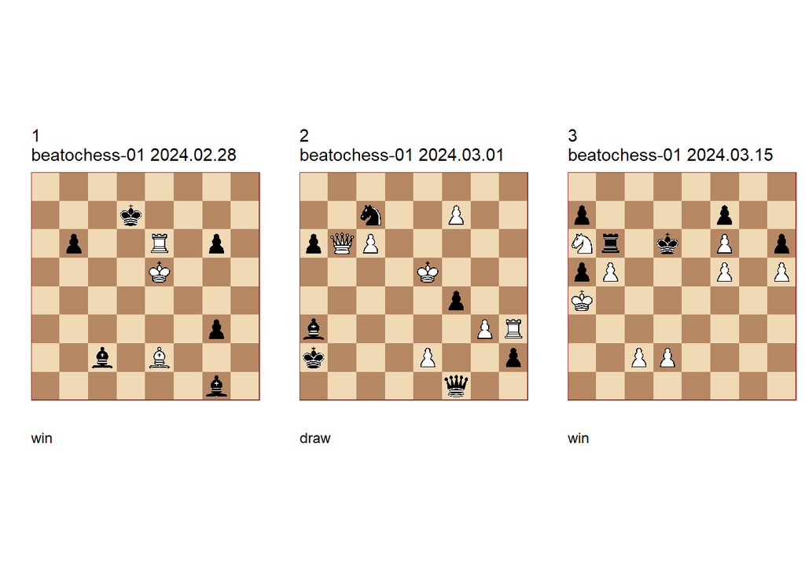

**1** correction of Gorgiev 1929 (+0170.02e5d7) U2. **1. Bb5+ Kd8 2. Rd6+ Ke7 3. Rd7+ Kf8 4. Kf6 Kg8 5. Bc4+ Kh8 6. Rd8+ Kh7 7. Bg8+ Kh6 8. Bb3 Bxb3** (8… Bd4+ 9. Rxd4 Bxb3 10. Rh4#) **9. Rh8# 1-0**.

**2** correction of Prokop 1929 (=4160.22e5a2) U3. **1. f8=Q** (1. Rxh2 fxg3 -/+) **1… Bxf8** (1… Qxe2+ 2. Kf5 Qe6+ (2… Bxf8 3. Qxc7) 3. Kg5 Be7+ 4. Kxf4 Nd5+ 5. Kf3 Nxb6 6. Rxh2+) **2. Rxh2 fxg3** (2… Bg7+ **main** 3. Ke4 fxg3 4. e3+ gxh2 5. Qb2+ (5. Qa5+ or ) (5. Qb3+ or ) ) **3. e4+ gxh2 4. Qf2+ Qxf2 1/2-1/2**.

**3** correction of Selzniev 1930 (+0301.34a4d4) U2. **1. c4** (1. Kxa5? Kd5) **1… Ke5** (1… Kd7 2. Nc5+! Kd6 (2… Kd8 3. Ne4 +-) 3. d4 +-) **2. d4+!** (2. c5? Rxf6 3. d4+ Kd5! 4. Kxa5 Rxf5 5. c6 Kd6 =) (2. Kxa5? Rd6 3. c5 Rxd2 4. Nb4 Rd1! 5. Ka6 Rb1! 6. c6 Kd6 7. Nd5 Rc1 8. Kb7 a6! 9. bxa6 (9. b6 Rxc6 =) 9… Rb1+ 10. Nb6 Kc5 11. c7 Rxb6+ 12. Ka7 Rc6 13. Kb7 Rb6+ 14. Kc8 Rxa6 15. Kd8 Rd6+ 16. Ke7 Rc6 =) **2… Kxd4** (2… Kxf6 3. c5 Rb7 4. c6 Re7 5. Kxa5 +-) **3. c5 Rxa6 4. c6 Kc5 5. c7 Kb6 6. c8=B! 1-0**.

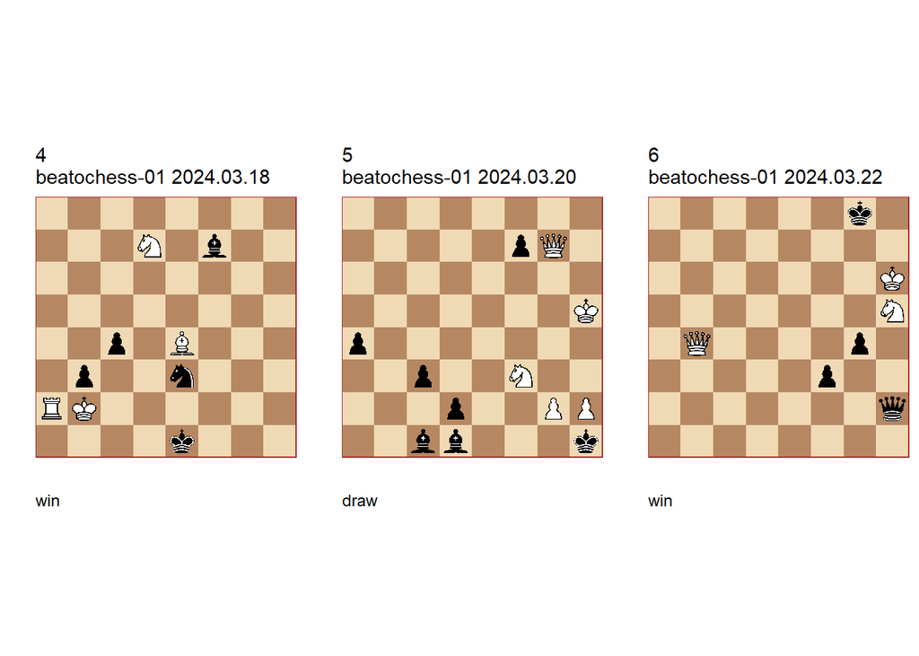

**4** correction of Gorgiev 1930 (+0144.03c1e1) U1. **1. Ra7** (1. Ra8? Nd1+ 2. Kc1 b2+ 3. Kc2 b1=Q+ 4. Kxb1 Nc3+ 5. Kc2 Nxe4) **1… Nd1+ 2. Kc1 b2+ 3. Kc2** (3. Kb1? Nc3+ 4. Kxb2 Nxe4 5. Nf6 Ng5 6. Re7+ Kd2) **3… b1=Q+ 4. Kxb1 Nc3+ 5. Kc1 Nxe4 6. Nf6! Ng5** (6… Nxf6 7. Re7+! Ne4 (7… Kf2 8. Rxf7) (7… Be6 8. Rxe6+ Kf2 9. Rxf6+) 8. Rxe4+ Kf2 9. Rf4+) **7. Re7+!** (7. Nh7? Nxh7 8. Re7+ Be6! (8… Kf2? 9. Rxf7+ Ke3 10. Rxh7) ) **7… Be6** (7… Kf2 **main** 8. Nh7! Nxh7 9. Rxf7+ Ke3 10. Rxh7) **8. Ne4! Nxe4 9. Rxe6 Kf2 10. Rxe4 1-0**.

**5** correction of Korolkov 1929 (=1061.23h5h1) U1. **1. Qg3 c2 2. h4 Bxf3+ 3. Qxf3 d1=Q 4. g4+ Qxf3 1/2-1/2**.

**6** correction of Zakhodyakin 1930 (+4001.02h6g8) U1. **1. Qe7 Qd2+ 2. Nf4!** (2. Kg6? Qc2+ 3. Kh6 Qc1+ =) **2… Qh2+ 3. Nh3!** (3. Kg6? Qc2+ 4. Kf6 Qc6+ 5. Ne6 Qc3+ =) **3… Qd2+ 4. Ng5** (4. Kg6? Qc2+ =) **4… Qh2+ 5. Kg6 Qc2+ 6. Ne4 1-0**.

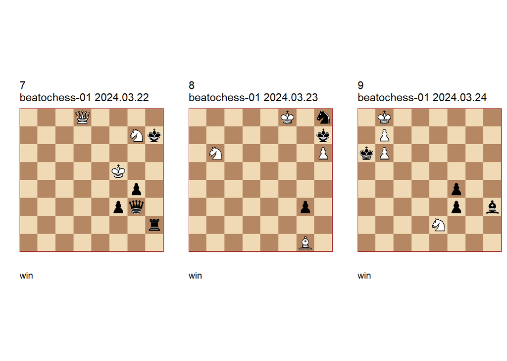

**7** modification of Zakhodyakin 1930 (+4001.02h6g8) U1. **1. Qe7 Kg8** (1… Qh4 2. Qf7 Kh8 (2… Qh6 3. Nh5+ Kh8 4. Qe8+ Kh7 5. Qe7+ Kh8 6. Qe5+ Kg8 7. Nf6+ +/-) 3. Qf8+ Kh7 4. Ne6 Qh5+ 5. Ng5+ (theme) 5… Qxg5+ 6. Kxg5 +-) **2. Kg6 Rh6+** ( 2… Qb8 3. Nf5 (theme) 3… Qb6+ 4. Nd6 Qb1+ 5. Ne4 (theme) 5… Qb6+ 6. Nf6+ (theme) ) **3. Kxh6 Qh2+ 4. Nh5** (theme) **4… Qd2+ 5. Nf4** (theme) **5… Qh2+ 6. Nh3** (theme) **6… Qd2+ 7. Ng5** (theme) **7… Qh2+ 8. Kg6 Qc2+ 9. Ne4** (theme) **1-0**.

**8** version of Zakhodyakin 1930 (+0018.01h7f8) U3. **1. Nd7!** (1. Be3? Ng6+ 2. Kf7 Ne5+ 3. Ke6 Nf3 =) (1. Nd5? Kxh6 =) **1… Kxh6** (1… Ng6+ 2. Kf7 Nh4 3. Nf6+ Kxh6 4. Be3#) **2. Kg8 Ng6 3. Be3+ Kh5 4. Kf7 Nh4** (4… g2 5. Nf6+ Kh4 6. Kxg6) **5. Nf6# 1-0**.

**9** correction of Zakhodyakin 1930 (+0031.22b8a6) U1 U2. **1. Nc3 f2 2. Kc7 f1=Q 3. b8=N+** (3. b8=Q? Qc4+ 4. Kd6 Qxc3) **3… Ka5 4. Nc6+ Ka6 5. b7 Qd3 6. b8=N#** (6. Nd5? Qh7+ 7. Nde7 Qb1) (6. b8=Q? Qd7#) **1-0**.

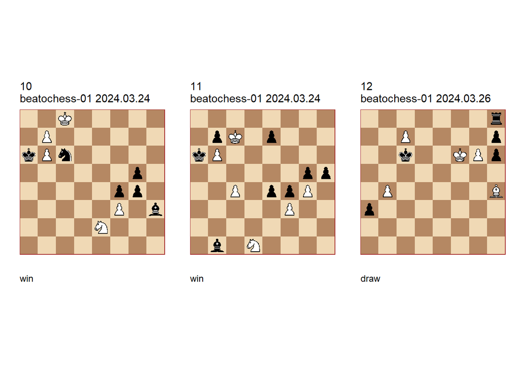

**10** modfication of Zakhodyakin 1930 (+0031.22b8a6) U1 U2. **1. Kc7 Nb8** (1… Bg2 2. Nd4 Nxd4 3. b8=Q +-) (1… gxf3 2. Kxc6 Bd7+ 3. Kc7 fxe2 4. b8=Q e1=Q 5. Qa8+ Kb5 6. Qd5+ Ka6 7. Qa2+ Kb5 8. Qb2+ Kc5 9. b7 +-) **2. Kxb8** (2. Nd4 gxf3 3. Nxf3 Bg2) (2. Nxf4 gxf3 3. Nxh3 g4 4. Kxb8 gxh3 =) **2… gxf3 3. Nc3** (3. Nd4? f2 4. Kc7 f1=Q 5. b8=Q Qc4+ 6. Nc6 Qf7+ 7. Kd6 Qe6+ 8. Kc5 Qe3+ =) **3… f2 4. Kc7 f1=Q 5. b8=N+ Ka5 6. Nc6+ Ka6 7. b7 Qd3 8. b8=N#** (8. Nd5 Qh7+ 9. Nde7 Qb1 =) **1-0**.

**11** modification of Zakhodyakin 1030 (+0031.22b8a6) U1 U2. **1. c5** (1. gxh5? e3) **1… e3 2. Nc3 e2 3. Nxe2 hxg4 4. c6 gxf3 5. Nc3 f2 6. cxb7 f1=Q 7. b8=N+! Ka5 8. Nc6+ Ka6 9. b7 Qd3 10. b8=N#! 1-0**.

**12** correction of Zakhodyakin 1931 (=0310.22f6c6) U3. **1. g7 a2** (1… Rc8 2. Bg3 a2 (2… h5 3. Kg5 a2 4. Be5 Re8 5. Kh4 Kb7 6. Kg3) 3. Be5 Kb7 4. Kf5 Re8 5. Kf4! (5. b5? Rxe5+) (5. Kg4? Kc6 6. Kf4 h5 7. Kg3 Kd5) 5… h5 6. Kg3 Kb6 (6… Kc6 7. Kh4) 7. Kh3 Kc6 (7… Kb5 8. Kg3 Kxb4 9. Kh4 Kc5 10. Ba1 Kc6 11. Kxh5) 8. Kh4 Kb7 (8… Kd7 9. b5) 9. Kg3) **2. gxh8=Q a1=Q+ 3. Kf7 Qxh8 4. Bd8 Kd7 5. c8=Q+ Kxc8 6. Bf6 1/2-1/2**.

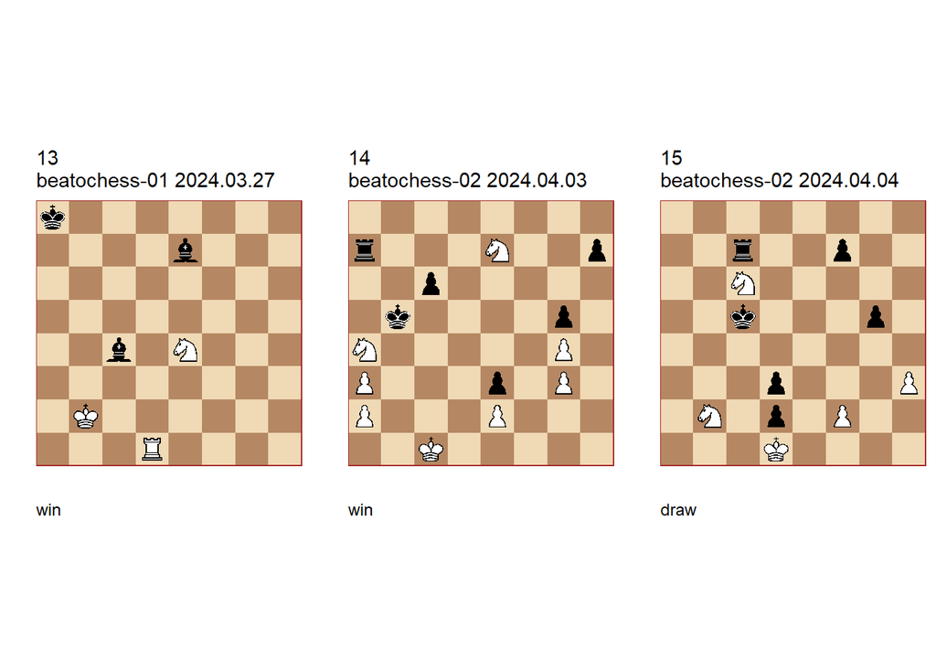

**13** version of Zakhodyakin 1933 (+0161.00b3a8) U2. **1. Rd7 Bh4** (1… Bb4 2. Rd4) **2. Rh7 Be1 3. Rh1 Bb4** (3… Ba5 4. Ra1 (4. Nc5 or ) ) **4. Ra1+ Kb7 5. Ra4 1-0**.

**14** correction of Zakhodyakin 1939 (+0302.33c2d5) U3. **1. Nc3+ Kc4 2. Nxc6 Rxa3 3. Kc2!!** (3. Nd1? Rxa2 4. Nxe3+ Kc3 5. Nd5+ Kc4 6. e4 Ra3) (3. Kb2 Rxc3 4. Ne7 (4. Na5+? Kb4 5. a3+ Rxa3 6. Nc6+ Ka4 7. Nd4 h6) 4… Kd4 5. Nf5+ Kc4) **3… Rxc3+ 4. Kb2 h6 5. Na5+ Kd4** (5… Kb4 6. a3+! Rxa3 7. Nc6+ Ka4 8. Nd4!) **6. Nb3+ Kc4 7. Nc5! Kd4** (7… Kb4 8. Na6+ Kc4 9. Nc7!) **8. Ne6+ Kc4 9. Nc7! Kd4** (9… Kb4 10. Nd5+) **10. Nb5+ 1-0**.

**15** correction of Zakhodyakin 1948 (=0302.03d1c5) U3. **1. Ne5 Kd4 2. Nf3+ Kc3 3. Na4+ Kb4** (3… Kb3 4. Nb6) **4. Nb6!** (4. Nb2? Rc2! 5. Nxd3+ Kc3 6. Ke2 Rc1! 7. Nxd2 Rc2) **4… Kc5 5. Na4+ Kb5 6. Nb2 Rc1+ 7. Kxd2 Rc2+ 8. Kxd3 Rxb2 9. Nxg5** (9. Ke3 f6) **9… Rxf2 10. Ne4 Rf1 11. Ke2 Rf4 12. Ke3 Rf1 13. Ke2 1/2-1/2**.

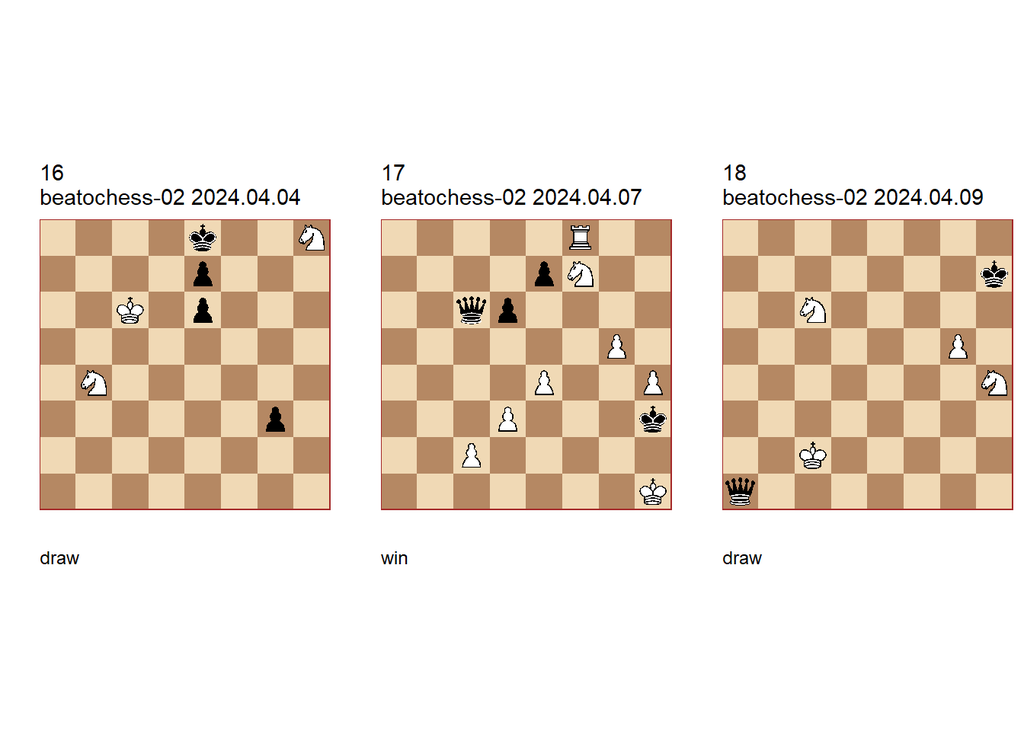

**16** correction of Zakhodyakin 1949 (=0002.02c8e8) U2. **1. Na6! g2 2. Nc7+ Kf8** ( 2… Kd8 3. Nxe6+ Kc8 4. Ng6 g1=Q 5. Nxe7+ =) **3. Nxe6+ Kg8 4. Nf7! g1=Q 5. Nfg5 1/2-1/2**.

**17** version of Zakhodyakin 1967 (+3200.33g1h4) U1. **1. g6 Qc3** (1… Qxc2 2. Ng5+ Kg3 (2… Kxh4 3. Rf1!) 3. Rf3+ Kxh4 4. Rf1) **2. Ng5+ Kxh4** (2… Kg3 3. Rf1) **3. Nf3+** (3. Rf1? Kh5!) **3… Kh5** (3… Kg3 4. Ng1 Qg7 5. Rf3+! Kh4 6. Kh2) **4. g7! Qxg7 5. Rf5+ Kh6** (5… Kg4 6. Rg5+) **6. Ne5!! dxe5** (6… Qg3 7. Nf7+ Kh7 8. Rh5+ Kg6 9. Rg5+) (6… Qg8 7. Nf7+ Kh7 8. Rh5+ Kg6 9. Rg5+) (6… Kh7 7. Rf7) (6… e6 7. Nf7+ Kh7 8. Rh5+ Kg8 9. Rg5) (6… Qh7 7. Rf2) (6… Qh8 7. Nf7+) **7. Rf2 1-0**.

**18** version of Zakhodyakin 1972 (=3002.10c2h7) U2. **1. g6+ Kh8 2. g7+ Kxg7** (2… Qxg7 **main** 3. Ne7! Qg4 (3… Qh7+ 4. Nhf5) 4. Nhf5 Qf3 5. Kd2! Qb3 6. Ke2!) **3. Nd4!** (3. Nf5+? Kf6 4. Nfd4 Qa3! 5. Kd2 Kg5!) **3… Kf6 4. Nhf3 1/2-1/2**.

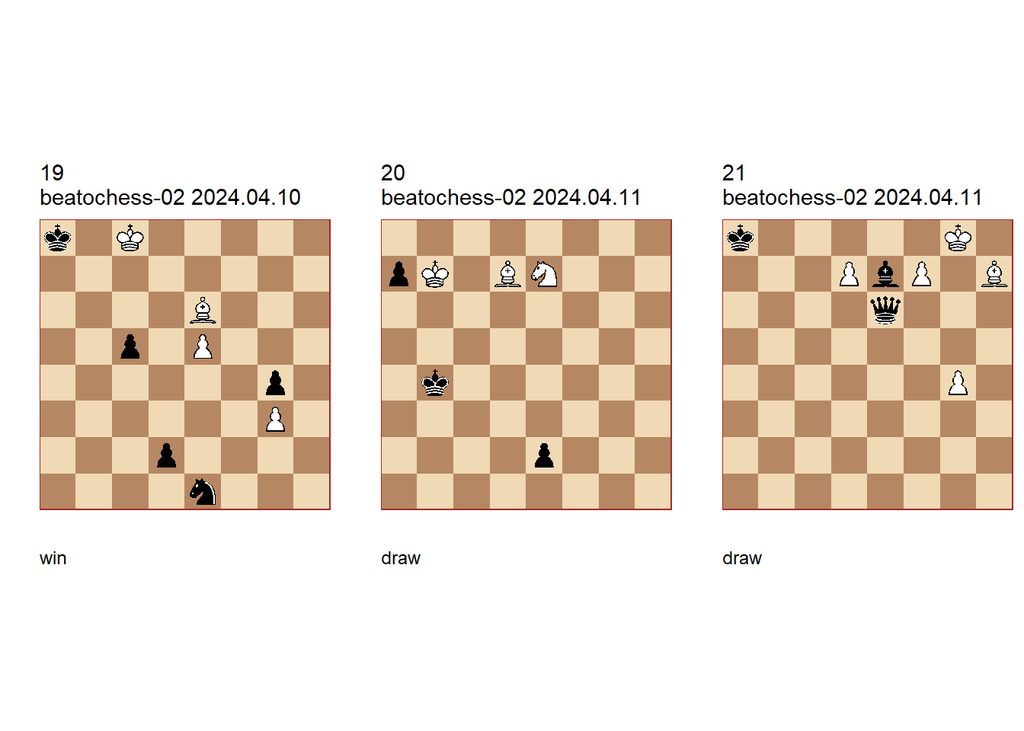

**19** correction of Zakhodyakin 1972 (+0013.12c8a8) U3. **1. Bb3!** (1. Bxg4? c4 2. e6 c3 3. Bd1 c2 4. Bxc2 Nxc2 5. e7 d1=Q 6. e8=Q Ka7 7. Qb5 Qg4+) **1… c4 2. Bd1!** (2. Ba4? Nf3 3. e6 Nd4 4. e7 Nf5 5. Kd8 Ng7 (5… Nxe7? is too slow ) 6. e8=Q Nxe8 7. Kxe8 Kb7 8. Kf7 Kb6 9. Kf6 Ka5 10. Bd1 Kb4 11. Ke5 Kc3) **2… c3 3. e6 c2 4. Bxc2 Nxc2 5. e7 d1=Q 6. e8=Q Ka7 7. Qb5!** (7. Qc6? Qf3 (7… Qb1 or ) ) **1-0**.

**20** correction of Zakhodyakin1980 (=0011.01b7b4) U2. **1. Nd5+ Ka5** (1… Kb3 2. Ba4+!) **2. Ne7!** (2. Kxa7? is one move too slow. White cannot reach the theoretical draw with the bishop on b7. 2… e1=Q 3. Bc6 Qf2+ (3… Qg1+? 4. Ka8 Qg8+ 5. Ka7 Qf7+ 6. Bb7) 4. Ka8 Qf8+ 5. Ka7 Qc5+ 6. Kb7 Qd6) **2… e1=Q 3. Nc6+ Ka4 4. Nd4+ Ka5 5. Nc6+ Kb5 6. Ne5+ Ka5 7. Nc6+ 1/2-1/2**.

**21** modification of Zakhodyakin 1980 (=3041.10g8h3) U3. **1. d8=Q+** (1. g5? Qxd7) (1. Bf5? Qd6) **1… Bxd8 2. Bf5** (2. g5? Be7 3. g6 Qc8+ 4. Kg7 Qf8#) **2… Qc4 3. g5** (3. Bd3? Qxg4+) **3… Bxg5 4. Bd3 Qa2** (4… Qd5 5. Be4) **5. Bb1 Qb3 6. Bc2 Qe6 7. Bf5 1/2-1/2**.

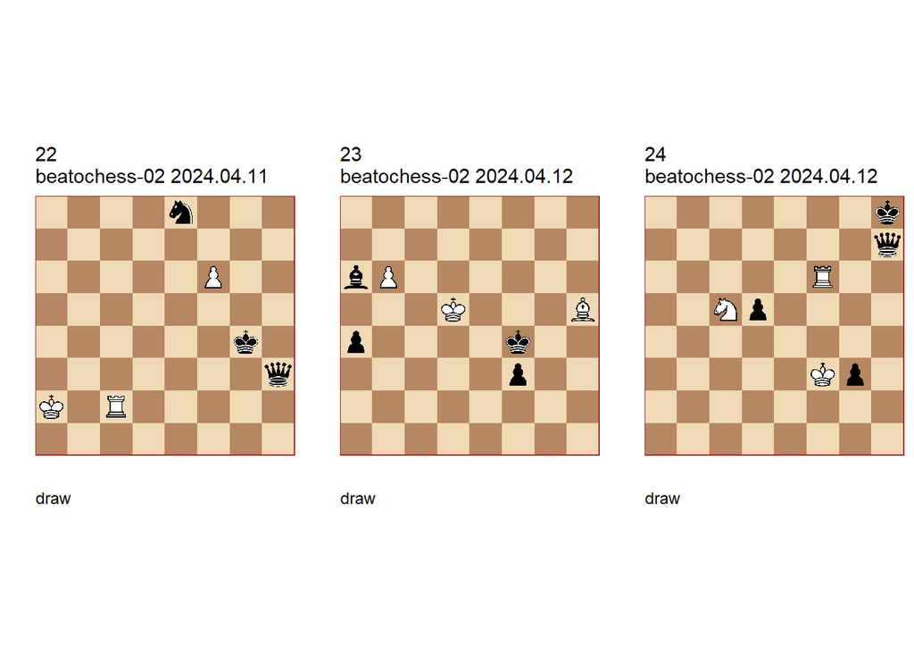

**22** correction of Zakhodyakin 1981 (=3103.10a2g4) U2 . **1. f7 Qh8 2. Rg2+** (2. Rc8? Qh2+ 3. Kb3 Qg3+ 4. Rc3 (4. Kb4 Qd6+) 4… Qb8+ 5. Kc2 Nd6) **2… Kf3 3. Rg8! Qh2+ 4. Rg2! Qh8 5. Rg8 Qh2+ 6. Rg2 Qxg2+ 7. Ka3 1/2-1/2**.

**23** correction of Zakhodyakin 1982 (=0040.12b3e4) U3. **1. Kd4!** (1. Bxf3? a3) **1… f2 2. Be2! a3** (2… Bxe2 3. b7 f1=Q 4. b8=Q+ = , e.g. 4… Kg4 5. Qg8+ Kh4 6. Qh7+ Kg3 7. Qg6+ Bg4 8. Qd3+) **3. Kc3 a2 4. Kb2 Bxe2 5. b7 a1=Q+ 6. Kxa1 f1=Q+ 7. Kb2 1/2-1/2**.

**24** correction of Zakhodyakin 1982 (=3101.01f3g7) U2. **1. Rf8+ Kg7 2. Ne6+ Kh6** ( 2… Kg6 3. Kxg3! (3. Nf4+? Kg5 4. Kxg3 Qh4+ 5. Kg2 (5. Kf3 Qh1+) 5… Qg4+ 6. Kf2 Qxf4+) 3… Qe7 4. Nf4+ Kg5 (4… Kg7 5. Rd8) (4… Kh7 5. Rh8+ Kg7 6. Rd8) 5. Nh3+ and Rf3 ) **3. Rf6+** (3. Kxg3 Qg6+) (3. Nf4 Qg7) (3. Rf4 Qd3+) **3… Kh5 4. Rg6!** (4. Nf4+ Kg5 (4… Kh4? 5. Rg6) 5. Rg6+ Kf5 6. Rxg3 Qh1+ is theoreatically lost ) **4… Qf7+** (4… Qxg6 5. Nf4+ Kg5 6. Nxg6 Kxg6 7. Kxg3) **5. Nf4+ Qxf4+ 6. Kxf4 Kxg6 7. Kxg3 1/2-1/2**.

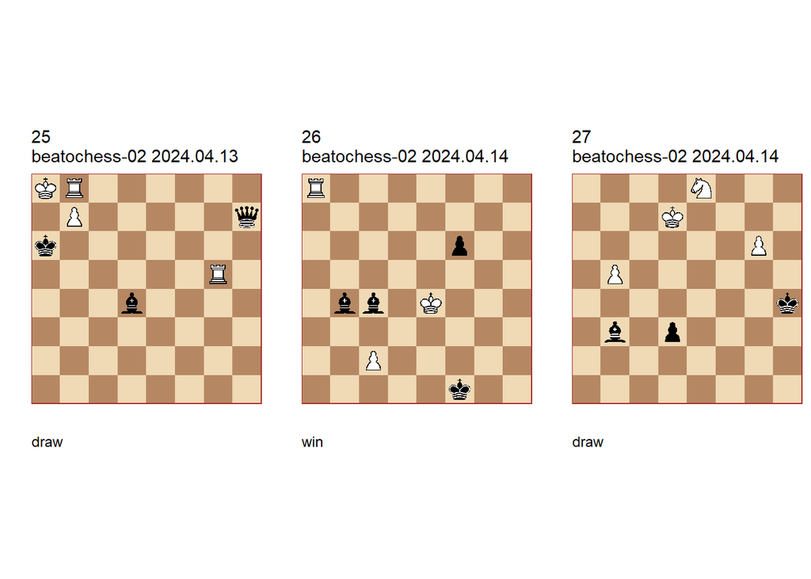

**25** correction of Zakhodyakin 1983 (=3230.10a8b6) U2. **1. Rb5!** (1. Rg4? Qe7! 2. Rxd4 (2. Rg6+ Bf6) 2… Qa3 3. Rd3 (3. Rg8 Kb6+ 4. Kb8 Qa7+ 5. Kc8 Qxb7+ 6. Kd8 Qb8+) 3… Qa5 (3… Qxd3? 4. Re8) 4. Rf8 Kb6+ 5. Kb8 Qa7+ 6. Kc8 Qxb7+ 7. Kd8 Qc7+ 8. Ke8 Qe5+ 9. Kd8 Qg5+ 10. Kc8 Qc5+ 11. Kd7 Qb5+) (1. Rd5) **1… Kxb5 2. Rh8!** (2. Re8 Qh1!) **2… Qe4 3. Rh4 Qf3 4. Rh3!** (4. Rxd4? Qa3+! 5. Kb8 Kb6) **4… Qc6 5. Rh6 Qg2 6. Rh2 Qd5 7. Rh5 1/2-1/2**.

**26** correction of Zakhodyakin 1983 (+0160.10e4f1) U2. **1. Ra4 Bf7** (1… f5+ 2. Kd4!) **2. Rxb4 Bg6+ 3. Ke3 Bxc2 4. Kd2** (4. Rb2? Bd1! (4… Ba4 or ) 5. Rb1 Ke1 6. Kd3 f5) **4… Bh7 5. Rh4 Bg8 6. Rf4+ 1-0**.

**27** correction of Zakhodyakin 1986 (=0031.11d7h2) U3. **1. Nd6** (1. Ng7? Kg4!) **1… d2 2. Nf5+ Kg4 3. Ne3+ Kf3 4. b6 Kxe3 5. b7 d1=Q+ 6. Ke7 1/2-1/2**.

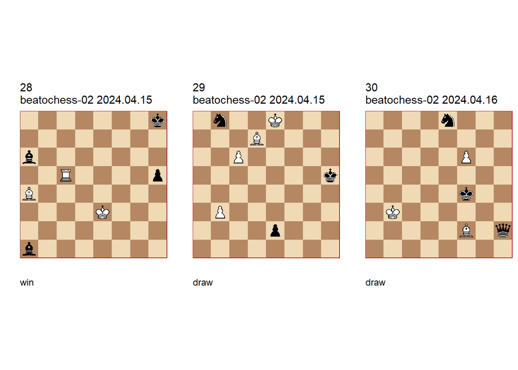

**28** correction of Zakhodyakin 1983 (+0170.01e6h1) U3. **1. Rc6** (1. Rxh5+? Kg7!) (1. Ra5? Bc4!) **1… Bb7** (1… Bf1 2. Rc1) **2. Rd6!** (2. Rb6? Bd5!) **2… Bg2** (2… Bg7 3. Rd8+ Kh7 4. Bc2+ Kh6 5. Rd6+ Kg5 6. Rg6+) **3. Rd8+ Kh7** (3… Kg7 4. Rd1) **4. Bc2+ Kh6 5. Rd6+ 1-0**.

**29** correction of Zakhodyakin 1983 (=0013.21e8h5) U3. **1. Bg4+! Kxg4 2. c7 e1=Q+ 3. Kf7 Qf1+** (3… Qf2+ 4. Kg8) **4. Kg7 Qa1+** (4… Nd7 5. c8=Q Qf6+ 6. Kg8 Qe7 7. Qc4+) **5. Kg8 1/2-1/2**.

**30** version of Zakhodyakin 1982 (=3016.10b3f4) U2. **1. f7 Qh3+** (1… Qh8 2. Bc5 Qh3+ 3. Kb4! (3. Kb2 Qg2+! 4. Kc1 (4. Ka3 Qa8+ 5. Kb2 Qb7+) 4… Qh1+ 5. Kb2 (5. Kd2 Qd5+) (5. Kc2 Qh7+) 5… Qb7+) ) **2. Bg3+!** (2. Kb4? Qh8 3. Bc5 Qb2+) **2… Qxg3+ 3. Ka4!** (3. Kb4? Qe1+) (3. Kc4? Nd6+) **1/2-1/2**.

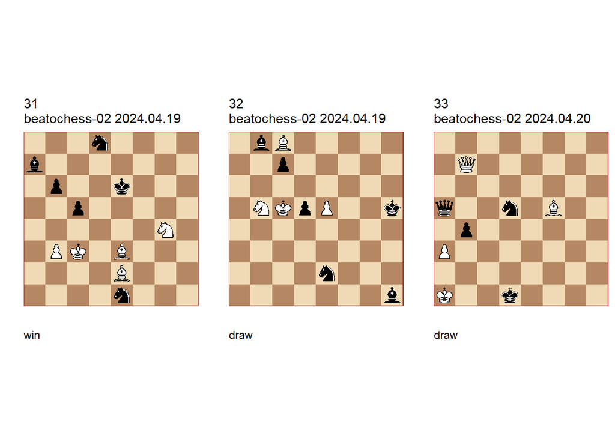

**31** correction of Zakhodyakin 1931 (+0027.01c3e6) U1 U2. **1. Bd2 Ng2 2. Bf1 Nf4** ( 2… Nh4 3. Bg5) (2… Kf5 3. Nh6+) (2… Nf4 3. Bxf4 Kf5 4. Bc7 Ne6 5. Ne3+ Ke4 6. Nd5 Kxd5 7. Bg2#) **3. Bxf4 Kf5 4. Bc7 Ne6 5. Ne3+ Ke4 6. Nd5 Kxd5 7. Bg2# 1-0**.

**32** correction of Zakhodyakin 1931 (=0074.10e5g6) U3. **1. e6 Ng3** (1… Kg6 2. Kc6 Kf6 3. Kd7 Be4 4. e7 Bg6 5. Bb7 Nf4 (5… d4 6. Be4 Bf7 7. Bd5) 6. Bc6 Bf5+ 7. Kd8 Ne6+ 8. Kc8 Nd4+ 9. Kb7 Nxb5 10. e8=N+ =) **2. e7** (2. Nxc7? Nf5! (2… Bxc7? 3. e7 Ne4+ 4. Kc6) 3. Nxd5 Bxd5 4. Kxd5 Ne7+ -/+) **2… Ne4+ 3. Kxd5** (3. Kc6 Nf6 4. Kb7 (4. Nd4 Ba7) 4… c6 5. Kxc6 j 5… Kg6 -/+) **3… Nf6+ 4. Ke6 Kg6 5. Nxc7!** (5. Bd7 Bd5+ 6. Ke5 c5+) **5… Bxc7** (5… Be4 6. Kd6! (6. e8=Q+? Nxe8 7. Nxe8 Bf5+ 8. Ke7 Bxc8 -/+) 6… Ne8+ 7. Kd7 Nxc7 8. e8=Q+ Nxe8 9. Kxe8) **6. e8=Q+! Nxe8 7. Kd7 Kf7 8. Bb7! Bxb7 1/2-1/2**.

**33** correction of Zakhodyakin 1931 (=4016.21a1c1) U3. **1. Bc2+! Kc1** (1… Kxc2 2. Qh7+ Kb3 (2… Kc3 3. Qh3+ Kc4 4. Kb2) 3. Qb1+ Kc4 4. Qe4+ Kc5 5. Qc2+ Kb5 6. Qd3+) **2. Ba4! Qxa4** (2… Qc5 3. Qg7) **3. Qxb4! Nxb4 1/2-1/2**.

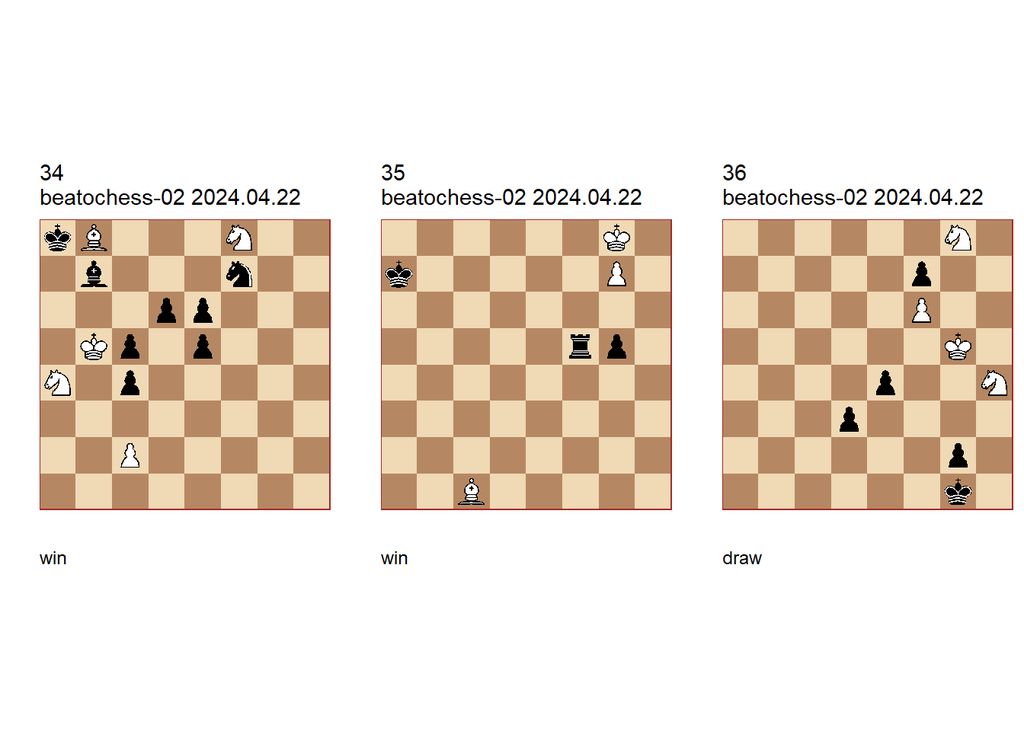

**34** correction of Zakhodyakin 1948 (+0014.13e4a6) U3. **1. Nd7** ( Black has sufficient material for equality after 1. Bc7) **1… Bc8 2. Nab6+ Kb7 3. Nxc8 Kxc8 4. Kc6 Nd8+** (4… e4 5. Bc7) **5. Kxd6 Kb7** (5… Nb7+ 6. Kxe6 Na5 7. Bxe5) **6. Nxe5! Kxb8 7. Kd7 Nb7 8. Nc6+ Ka8 9. Kxe6 c3 10. Ke5! c4 11. Kd5 1-0**.

**35** correction of Zakhodyakin 1962 (+0310.10g8a7) U2. **1. Kh8 Rb5 2. Be3+ Ka8 3. Bc5 Rb8+ 4. Bf8 Rb1 5. g8=Q** (5. Bd6? Rh1+ 6. Kg8 Rh6 7. Kf7 Rh7) **5… Rh1+ 6. Bh6+ 1-0**.

**36** correction of Zakhodyakin 1962 (=0002.03g5g1) U3. **1. Nh6 d2 2. Ng4 d1=Q 3. Nxg2! Qd5+** (3… Kxg2 4. Ne3+) **4. Kh4!** (4. Kh6? Qf5 (4… Qd2+? 5. N2e3 ) ) (4. Kf4 Qd6+) **4… Qf5 5. N2e3 1/2-1/2**.

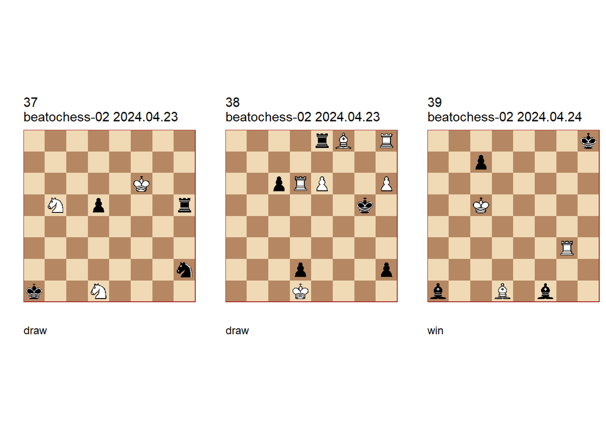

**37** correction of Zakhodyakin 1965 (=0305.01f4b1) U2. **1. Nd4** (1. Ndc3? Kb2 2. Ke6 d4) (1. Ke6? Nf3) **1… Ng4+** (1… Rh3 2. Ne3 Nf3 3. Ne6) **2. Ke6 Rh3 3. Kxd5 Rd3 4. Ne3! Nxe3+ 5. Ke4 Rc3 6. Nb5 Rb3 7. Nd4 Ra3 8. Nb5 Ra5 9. Nd4 Ra3 10. Nb5 Rb3 11. Nd4 Rc3 12. Nb5 Rc5 13. Nd4 Rc3 14. Nb5 1/2-1/2**.

**38** correction of Zakhodyakin 1965 (=0510.12d1h6) U1 U2. **1. Be7+! Rxe7 2. Rg8+ Kh5** (2… Kf6 3. Rf8+ Ke5 4. Rf1 Kxd6 5. Rh1) (2… Kh4 3. Rd4+) **3. Rd5+! cxd5 4. h7! h1=Q+ 5. Kxd2 Qh2+ 6. Kd1 Qh1+ 7. Kd2 Rxh7 8. e7 Qh2+ 9. Kd1 Qh1+ 10. Kd2 1/2-1/2**.

**39** modification of Zakhodyakin 1969 (+0170.00d3a8) U2 U1. **1. Rf3 Bg2 2. Rf4 Bb7 3. Rb4 Bg2 4. Rh4+ Kg8 5. Rg4+ 1-0**.

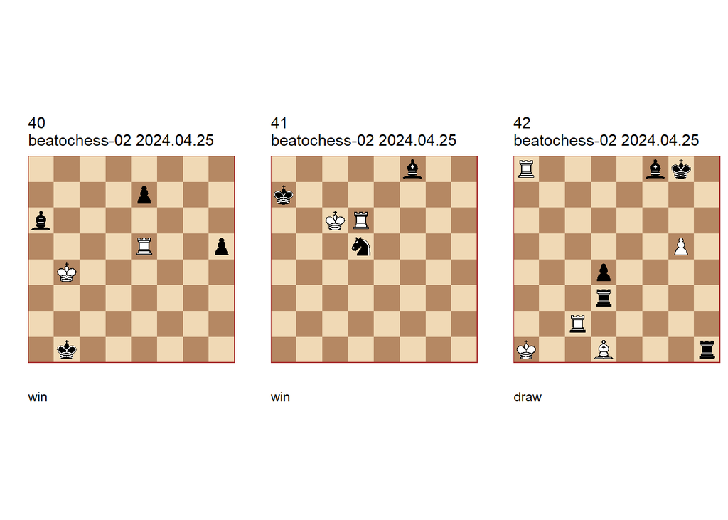

**40** correction of Zakhodyakin 1978 (+0130.01b4b1) U2. **1. Kc3 e6 2. Re4!** (2. Rg5? h4!) (2. Rxh5? Bc8!) **2… Bc8** (2… h4 3. Rb4+ (3. Rxh4 Bc8) 3… Kc1 4. Ra4) (2… e5 3. Rxe5 or 3.Rb4+ ) **3. Kb3 Kc1 4. Rc4+ 1-0**.

**41** version of Zakhodyakin 1979 (+0133.00c6a7) U3. **1. Rd7+ Kb8** (1… Ka6 2. Rxd5!) (1… Nc7 2. Rxc7+ ( or 2. Kxc7) 2… Kb8 3. Rh7 Ba3 4. Rh1 Be7 5. Rh8+ Ka7 6. Rh7) **2. Rd8+ Ka7 3. Rxf8!** (3. Rxd5? Bh6!) **3… Nb4+ 4. Kb5 1-0**.

**42** correction of Zakhodyakin 1971 (=0840.11a1g8) U1. **1. Kb2!** (1. Rf2? Rhxd1+ 2. Kb2 R1d2+ 3. Rxd2 Rxd2+ 4. Kc1 Rd3 5. Kc2 Rc3+ 6. Kd2 Kf7) **1… Rhxd1** (1… Rdxd1 2. Rf2) **2. Rxf8+! Kxf8 3. Rf2+ Kg8 4. Kc2 Kg7 5. Re2!** (5. Rh2? Ra3 6. Kxd1 Ra1+) (5. Rg2? Kg6) **5… Kg6 6. Rg2 1/2-1/2**.

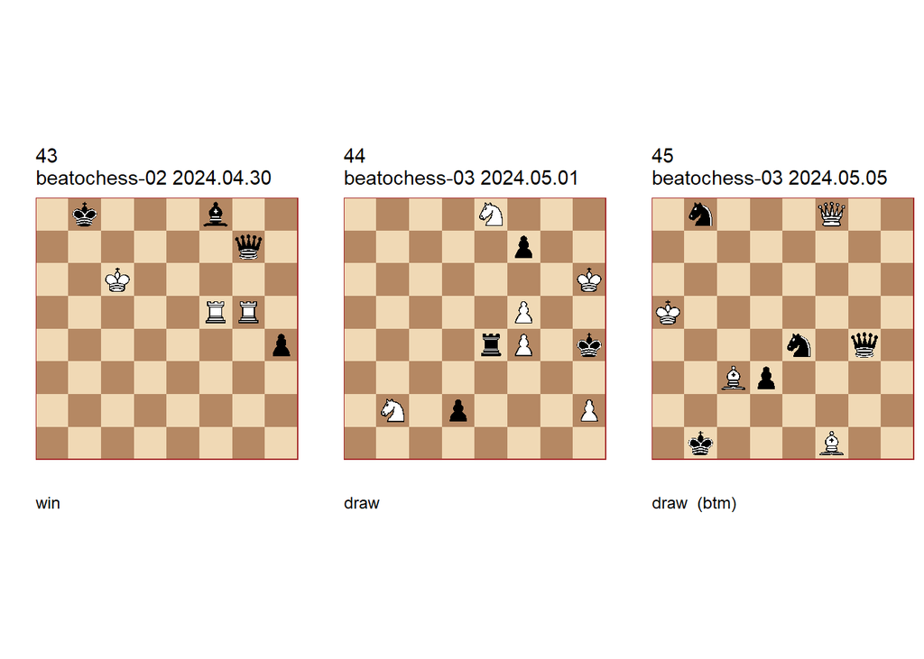

**43** correction of Zakhodyakin 1981 (+3230.00c6b8) U2. **1. Rb5+ Ka8 2. Ra5+ Qa7** ( 2… Kb8 3. Rgb5+) **3. Rxa7+** (3. Rgd5? Qxa5) **3… Kxa7 4. Rg4! Bh6** (4… h3 5. Rh4 h2 6. Rxh2 Bb4 (6… Bg7 7. Rh7) 7. Ra2+ Kb8 8. Rb2) **5. Kc7 Ka6 6. Rg6+ 1-0**.

**44** modification of Zakhodyakin 1981 (=0302.01g8h4) U3. **1. Nf6!** (1. Nd6? Rb4! 2. Nd1 Rb6) **1… Re1** (1… Rxf4 2. Kg7 Kg5 3. Kxf7) **2. h3!** (2. Nd1? Rxd1 3. Ne4 Rf1! 4. Nxd2 Rxf4 5. Kg7 Rxf5 6. Ne4 Rf1! 7. Nf6 Kg5 8. Nh7+ Kg4 9. Nf6+ Kf5) **2… Rb1** (2… Kxh3 3. Kg7) **3. Nd1! Rxd1 4. Ne4 Rf1 5. Nxd2 Rxf4 6. Kg7 Rxf5 7. Ne4 Rf1 8. Nf6 Kg5 9. Nh7+ Kh5 10. Nf6+ Kg5** (10… Kh4 11. Kxf7 Kg5 12. h4+) **11. Nh7+ 1/2-1/2**.

**45** correction of Zakhodyakin 1979 (=4016.00a6b8) U3. **1… Qh5+ 2. Kb4** (2. Kb6? Nd7+) (2. Ka4? Nxc3+) **2… Nc6+** (2… Na6+ 3. Kc4 d2 4. Bd3+ Ka2 5. Bxd2 Nxd2+ 6. Kc3 Qa5+ 7. Kc2) **3. Ka3** (3. Kc4? d2 4. Bd3+ Ka2 5. Bxd2 (5. Qa8+ Na5+) 5… Nxd2+ 6. Kc3 Qa5+ 7. Kc2 Nd4+ 8. Kd1 N2f3) **3… Qd5 4. Bxd3+! Qxd3 5. Qc5!! Qa6+** (5… Nxc5 =) (5… Nxc3 6. Qxc6 =) **6. Ba5 Qd3+** (6… Nxa5 7. Qb5+! Qxb5 =) **7. Bc3 1/2-1/2**.

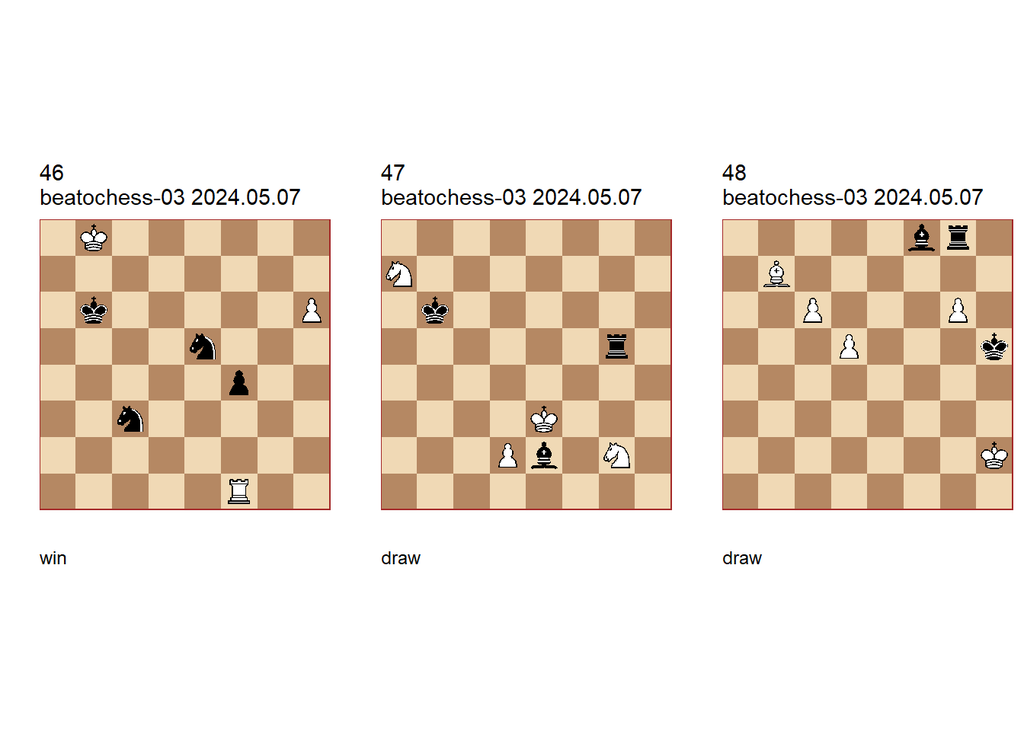

**46** correction of Zakhodyakin 1982 (+0106.11d8d6) U1 U3. **1. h7** (1. Rxf4? Nd5! 2. h7 (2. Rf5 Ne7) 2… Ng6 3. Rg4 Nde7) **1… Ng6 2. Rg1** (2. Re1? Kb5!! ( 2… Kc5 3. Re6 Nh8 4. Re8) 3. Re6 Nh8 4. Re8 Nd5 5. Rxh8 Nf6 6. Kc7 Kc4 7. Kd6 Kd3 8. Ke5 Nxh7 =) **2… Nh8 3. Rg8 Ne4 4. Rxh8 Nf6 5. Ka8! Ka6** (5… Ka5 **main** 6. Rf8! (6. Rg8? Nxh7 7. Rg7 Nf6) 6… Nxh7 7. Rf7 Ng5 (7… Kb4 8. Rxh7 Kc3 9. Rf7) 8. Rf5+) **6. Rg8!** (6. Rf8? Nxh7 7. Rf7 Ng5 8. Rf6+ Kb5 9. Rf5+ Kc4 10. Rxg5 Kd3) **6… Nxh7 7. Rg7 Nf8 8. Rf7 Ne6 9. Rf6 1-0**.

**47** correction of Zakhodyakin 1982 (=0332.00f3c6) U1 U3. **1. Nc8+ Kc7 2. Ne7 Re5+ 3. Kf2 Rxe7 4. Ne3 1/2-1/2**.

**48** correction of Zakhodyakin 1982 (=0340.20h2h5) (U1). **1. c7!** (1. Kh1? Rg7) **1… Bd6+ 2. Kh1!** (2. Kh3? Bxc7 3. d6 Bxd6 4. Bd5 Re8 5. g7 Re3+ 6. Kg2 Rg3+) **2… Bxc7 3. d6! Bxd6 4. Bd5! Rg7 5. Bf7 1/2-1/2**.

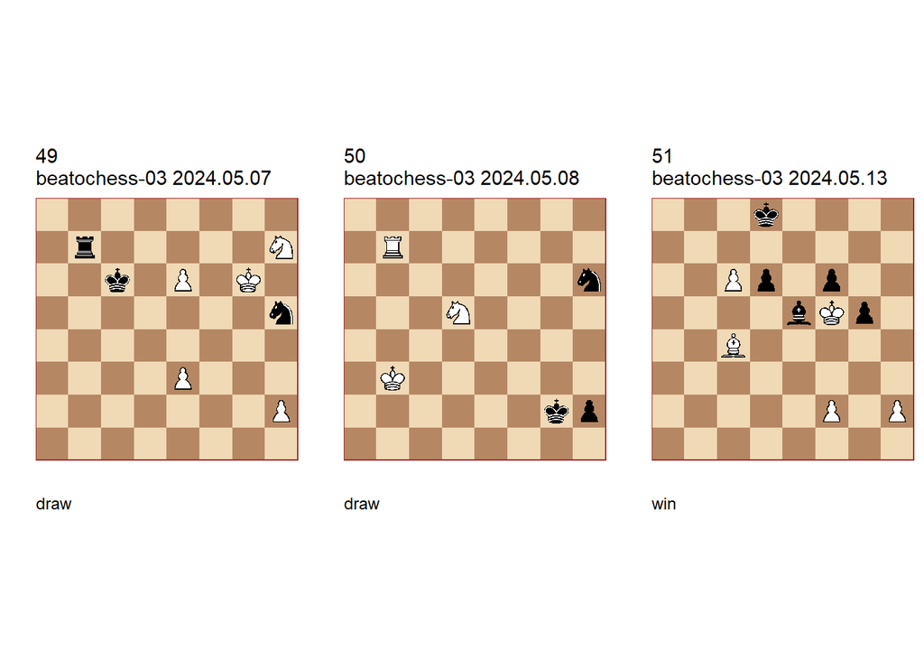

**49** correction: of Zakhodyakin 1983 (=0304.20g6c6) U3. **1. Ng5 Ng7 2. Nf7 Nxe6 3. Kf6 Kd7 4. Ne5+ Kd6 5. Nf7+ Kd7** (5… Kd5 6. e4+) **6. Ne5+ 1/2-1/2**.

**50** correction: of Zakhodyakin 1948 (=0104.01b2g2) U1. **1. Ka2** (1. Nf4+ Kf3) (1. Ne3+ Kf3) **1… h1=Q 2. Rb1 Qh4 3. Rb2+ Kf3 4. Rb3+ Ke2 5. Rb2+ Kd3 6. Rb3+ 1/2-1/2**.

**51** correction of Weenink 1918 (+0040.32f5d8) U3. **1. f4! gxf4** (1… Bxf4 2. h4 d5 3. Bxd5 Ke7 4. h5) **2. h4** (2. Bd5? f3 3. Bxf3 Bxh2) **2… d5 3. Bxd5** (3. h5? Ke7 4. h6 Kf8 5. Bxd5 f3 6. Bxf3 Kg8) **3… Ke7 4. Kg6!** (4. h5 Kf8 5. h6 f3 6. Bxf3 Kg8) **4… Kf8 5. Kh7! f5** (5… f3 6. Bxf3 f5 7. h5 ( or 7. Bd5) ) **6. h5!** (6. Bf3? Kf7 7. h5 Kf6 8. h6 Kg5) **6… f3 7. Bxf3 Kf7 8. h6!** (8. Bd5+? Kf6 9. h6 Kg5) **8… Kf6** (8… Bc7 9. Bd5+ Kf6 (9… Kf8 10. Kg6) 10. Kg8) **9. Kg8! 1-0**.

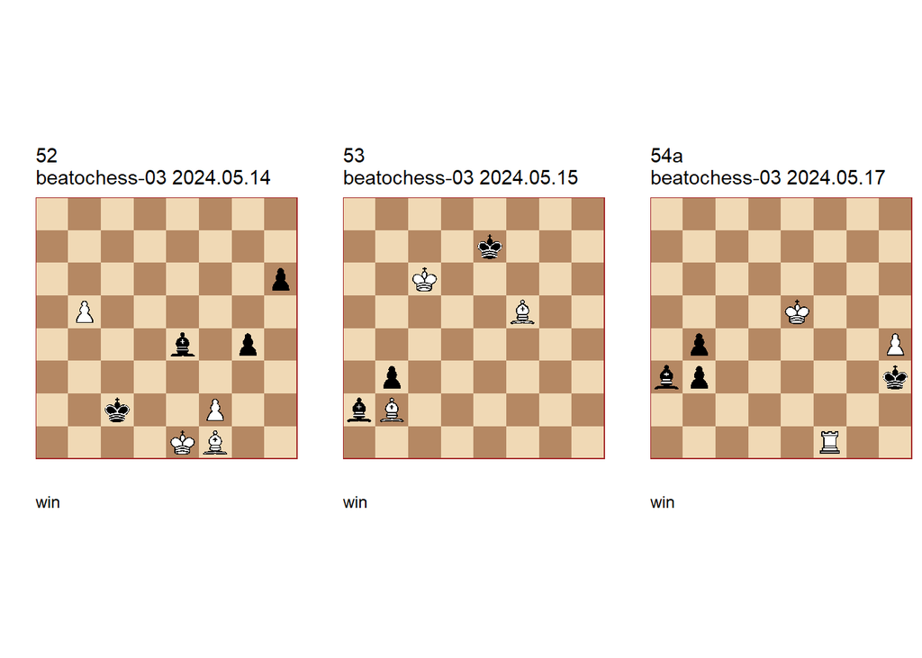

**52** Tijdschrift v.d. KNSB/7. U3: (HHdbII#06604 2000). **1. b6 Bb7** (1… h5 2. Ba6 h4 3. b7 Bxb7 4. Bxb7 g3 (4… Kd3! **cook** 5. Bc6 Kd4 6. Ke2 Ke5 7. Ke3 Kf5 8. Bd7+ (8. Be4+ Ke5 9. Bc2 Kf6 10. Bd1 Kf5 11. Be2 Kg5 12. Ke4 h3! 13. Bf1 g3 14. f4+ Kh4) 8… Kg5 9. Ke4 Kh5 10. Kf4 g3) 5. f4 h3 6. Kf1) **2. Bg2! Bxg2 3. f4! g3** (3… gxf3 **main** 4. Kf2!) (3… h5 **main** 4. Kf2 Bd5 5. Kg3 ) **4. f5 h5 5. f6 h4 6. f7 h3 7. f8=Q h2** eg **8. Qf5+ Kb2 9. Qe5+ Kb1 10. Qb5+ Ka1 11. Qa5+ Kb1 12. Qb4+ Ka1 13. Qd4+ Kb1 14. Qd1+ Kb2 15. Qd2+ Kb1 16. Qxg2 1-0**.

**53** Tijdschrift v.d. KNSB/10. U2: Ulrichsen=J HHdbIII#60576 13-2-2003. U1: Neuenschwander=B beatochess 2024. **1. Kc7** (1. Kc5 /Kd5/Be4/Bd3/Bg6/Bh7 **cook** **BN** ) **1… Ke8 2. Kd6 Kf7 3. Kd7 Kf8 4. Bg6 Kg8 5. Ke6 Kf8 6. Bf7 Bb1 7. Kf6** ( 7. Bh8! **cook** JU ) **7… Bf5 8. Ba3# 1-0**.

**54a** twin (a) version of Weenink 1919 (+0130.11c2g4) U2. **1. Rh1+!** (1. h5? Bb2+ 2. Kf5 (2. Ke4 Bg7! 3. Rh1+ Kg2!) 2… Bc3! 3. h6 b2! (3… Kg2? 4. Rb1! b2 5. Ke4!) 4. h7 Kg2! 5. Rb1 Kf3) **1… Kg4 2. h5 Bb2+ 3. Ke4 Kg5 4. h6 Kg6 5. h7 Bh8 6. Kd3 b2 7. Kc2 b3+ 8. Kb1** eg **8… Kg5 9. Rh3 Kg6 10. Rh2 Kg5** (10… Kf7 11. Rg2 Bg7 12. Rg3) **11. Rxb2 Kg6 12. Rh2 Kg5 13. Rh1 Kg6 14. Rh3 b2 15. Rh2 Kf7 16. Rg2 1-0**.

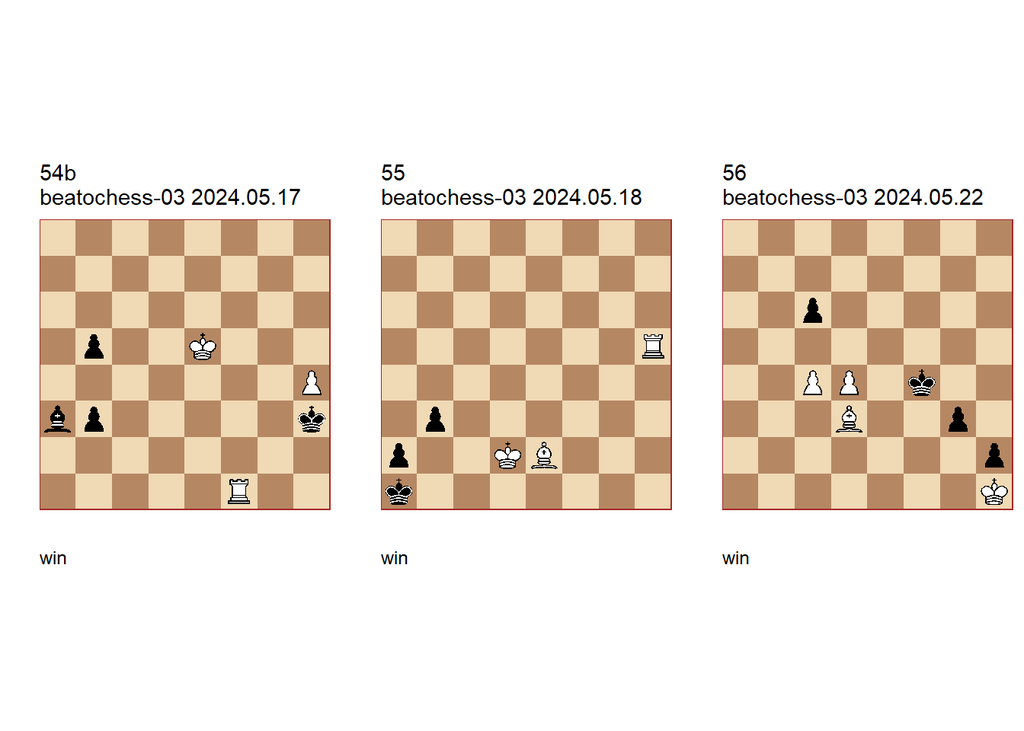

**54b** twin (b) version of Weenink 1919 (+0130.11c2g4) U2. **1. h5!** (1. Rh1+? Kg3! (1… Kg4? 2. h5 Bf8 3. h6) 2. h5 Bf8! 3. h6 Kg2!) **1… Bb2+** (1… b2 2. Rb1) **2. Kf5!** (2. Ke4? Bg7!) **2… Bh8** (2… Kg2 3. Rb1!) (2… Bg7 3. Rf3+) **3. Rf3+!** (3. h6? b2) **1-0**.

**55** correction of Weenink 1919 (+0110.02d2b1) U1. **1. Bc4 Kb1** (1… b2 2. Bxa2 Kxa2 3. Ra5+ Kb3 4. Rb5+) **2. Rh1+ Kb2 3. Rh3 a1=Q 4. Rxb3+ Ka2 5. Kc2 Qd4 6. Rc3+ 1-0**.

**56** correction of Weenink 1919 (+0010.12h1g8) U1. **1. Bf1!** (1. d5? cxd5 2. cxd5 Ke5 3. Bc4 (3. Be4? Kxe4 4. d6 Kf3 5. d7 Kf2 6. d8=Q g2+ 7. Kxh2 g1=Q+ 8. Kh3 Qg3#) 3… Kd6) **1… Ke4 2. d5 cxd5 3. Bg2+** (3. c5 Ke5) **3… Kf4 4. cxd5** (4. Bxd5 Ke5 5. Kg2 Kd4 6. Kxg3 h1=Q 7. Bxh1 Kxc4) **4… Ke5 5. Bf3 Kf4 6. Kg2 h1=Q+ 7. Kxh1 Kxf3 8. Kg1 1-0**.

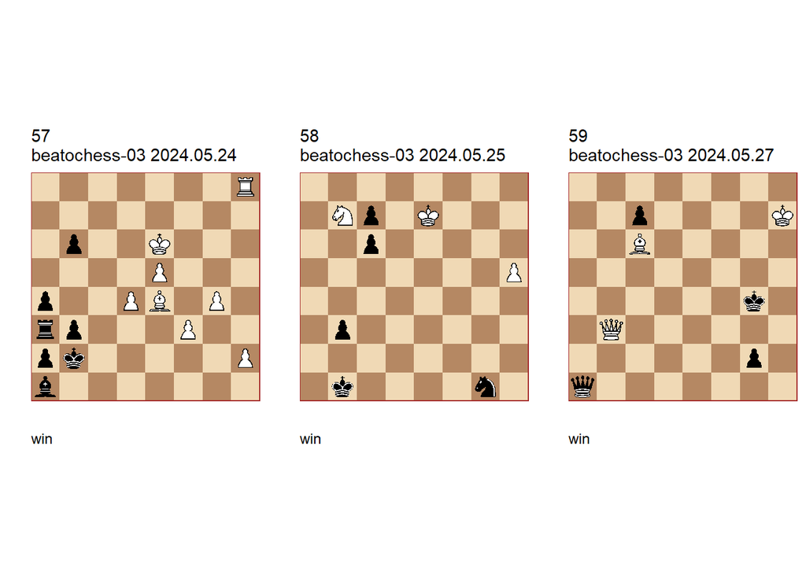

**57** correction of Weenink 1922 (+0440.44g5b2) U1. **1. Rc8 b5 2. Bh7! b4 3. Kf5 Kb1 4. Kf4+ Kb2 5. Ke4 Kb1 6. Ke3+ Kb2 7. Kd3 Kb1 8. Kd2+ Kb2 9. Bg8! Kb1 10. Rc1+ Kb2 11. Rc6 Kb1 12. Bh7+ Kb2 13. Rg6! Kb1 14. Rg5+** (14. Rf6+ or ) **14… Kb2 15. Rf5 Kb1 16. Rf4+ Kb2 17. Re4 Kb1 18. Re3+ Kb2 19. Rd3 Kb1 20. Rxb3# 1-0**.

**58** version of Weenink 1914 (+0004.11e7b1) (s) U2 **1. Nc5!** ( try 1. Na5? b2 2. Nc4 Nf3 3. Kf6 Nd2 4. Nxb2 Kxb2 5. h6 c5 6. h7 c4 7. h8=Q c3 8. Kf5 Kb3 9. Qb8+ Ka3) **1… b2** (1… Kc2 2. Nxb3 Kxb3 3. h6 c5 4. h7 c4 5. h8=Q c3 6. Qb8+) **2. Na4 Nf3 3. Kf6!** (3. Nxb2? Kxb2 4. Kf6 c5 5. h6 c4 6. h7 c3 7. h8=Q c2) **3… c5** (3… Kc2 4. Nxb2 Kxb2 5. h6 c5 6. h7 c4 7. h8=Q c3 8. Kf5! (8. Qb8+? Kc1) 8… c5 9. Qb8+ eg 9… Kc1 10. Ke4 c2 (10… Nd2+ 11. Kd3) 11. Kxf3) **4. h6 c4 5. h7 c3 6. h8=Q** (6. Nxc3+? Kc2 7. h8=Q Kxc3 8. Qh7 Nd2) **6… c2 7. Nc3+ Kc1** (7… Ka1 8. Qa8#) **8. Qh6+ Nd2 9. Qh1+ 1-0**.

**59** correction of Weenink 1920 (+4010.01h7g4) (c) (U1). **1. Qf3+** (1. Qe6+? Kg3! 2. Qe3+ Kh2!) **1… Kg5 2. Qxg2+** (2. Qg3+ loses time 2… Kf5 3. Qg6+ Kf4 4. Qe4+ Kg5 5. Qxg2+ = **main** line ) **2… Kf5 3. Qg6+ Kf4 4. Qe4+ Kg3 5. Qf3+ Kh4 6. Bd7! Qb1+ 7. Bf5 Qb4 8. Qe3! Qd6 9. Bc8! Qh2 10. Be6 c5 11. Kh6! 1-0**.

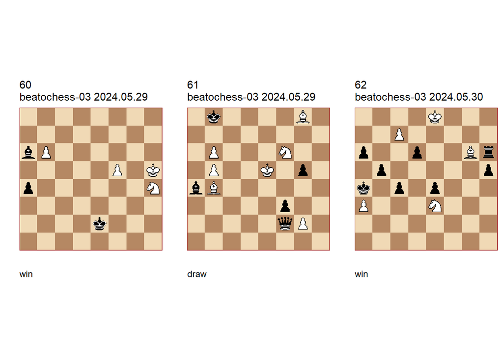

**60** correction of Badai 1964 (+0001.12g5e2) U2. **1. Nf3!** (1. f6? a3 2. Nf5 Kd2! 3. Nd4 Bc4 4. b7 a2 5. b8=Q a1=Q) **1… a3 2. Nd4+** (2. f6? Bc4!) **2… Kd3 3. f6** (3. Nb3? Kc4! 4. Nc1 Kd5 5. f6 Kd6! 6. Kg6 Bc4) **3… Kc3** (3… a2 4. Nb3 Kc3 5. Na1 Kb2 6. f7 Kxa1 7. f8=Q) **4. Nb5+! 1-0**.

**61** correction of Dobrescu 1970 (=3051.32e5b8) U1. **1. Bd6+** (1. Bd5? Qe2+ 2. Be4 (2. Ne4 Qb2+) 2… Qxb5+) **1… Kc8** (1… Kb7 2. Bd5+) **2. Be6+ Kb7** (2… Kd8 3. Bc7+ Ke7 4. Bd6+) **3. Bd5+ Kxb6 4. Bc5+! Qxc5** (4… Kxc5 5. Ne4+ Kxb5 6. Nxf2 fxg2 7. Bxg2) **5. Nd7+ Kxb5 6. Nxc5 f2!** (6… Kxc5 7. Bxf3) (6… fxg2 7. Bxg2) **7. Ne4! f1=Q 8. Bc4+ Qxc4 9. Nd6+ Kb4** (9… Kc5 10. Nxc4) **10. Nxc4 Kxc4 11. Kf5 1/2-1/2**.

**62** correction of Holm 1912 (+0311.24e7a4) U1. **1. Ke7! Rh8 2. Nxc4!** (2. Be8? Rh7+ 3. Bf7 Rh8 4. Nxc4 d5! 5. Nb6+ Kxa3 6. Bxh5 Rh7+ 7. Bf7 Rh8) **2… h4!** (2… d5 3. Nb6+ Kxa3 4. Kf7 h4 5. Kg7) (2… bxc4 3. Be8+) **3. Bh5! Kb3 4. Be8 Rh7+** (4… h3 5. c8=Q h2 6. Qxa6 h1=Q 7. Qxb5+ Kc2 8. Qb2+ Kd3 9. Bb5 Qh7+ 10. Kxd6 Rd8+ 11. Kc5 Qe7+ 12. Nd6+ Ke3 13. Qe2+ Kf4 14. Qf2+ Kg5 15. Qe3+ Kh5 16. Be2+ Kg6 17. Qxe4+) **5. Bf7 Rh8 6. Nxd6+ Kb2 7. Bg8! Rxg8** (7… h3 8. c8=Q h2 9. Nxe4 h1=Q 10. Qc3+ Kb1 11. Nd2#) **8. Ne8 e3 9. c8=Q e2 10. Qe6 Rg2** eg **11. Nf6 h3 12. Qe4 1-0**.

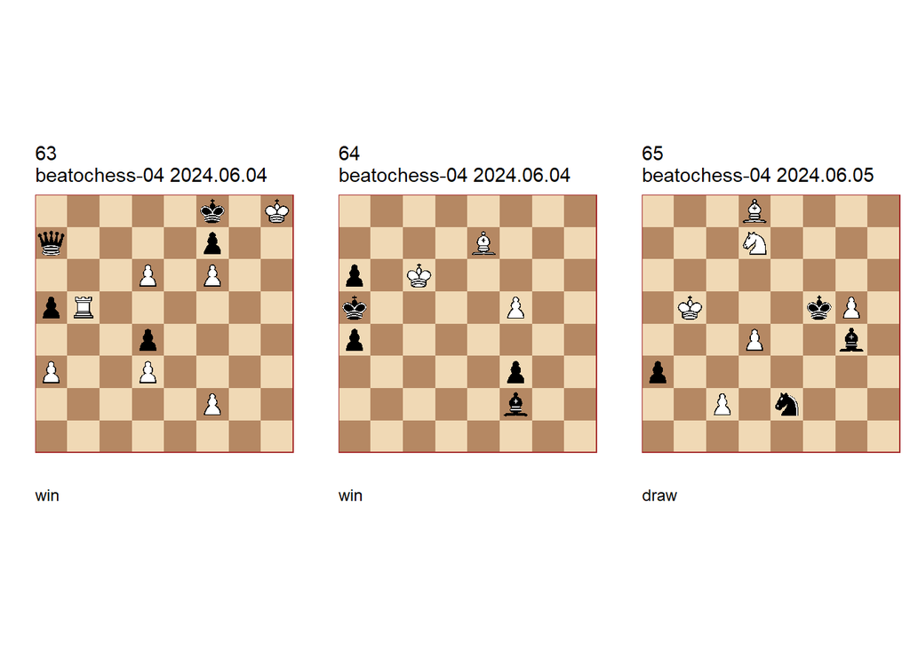

**63** version of Aizenshtat 1931 (+3100.52h7f8) U2. **1. d7 Qc7 2. f4 Qd8 3. Kh7 Qa8 4. Rb1!** (4. Rb7? a4! 5. Kh8 Qd8 6. Kh7 Qa8 7. Rb1 Qh1+ 8. Rxh1) **4… a4 5. Rb7! Qd8 6. Rb2!** (6. Ra7? Qa5!) **6… Qa8 7. Rg2! 1-0**.

**64** correction of Aizenshtat 1931 (+0040.13c6a5) U2. **1. f6 Bd4** (1… Be3 **main** 2. f7 Bh6 3. Bg5! Bf8 4. Bd2+) (1… Bh4 2. Bd8+ Kb4 3. f7) **2. f7 Bg7 3. Bf6! Bf8 4. Bc3+ 1-0**.

**65** correction of Videnkin 1930 (=0044.21b4e5) U3. **1. Nc5** (1. Bf6? Nc3+ 2. Kb4 a2) **1… Nxd4+ 2. Kb4 a2 3. Nb3 Nxb3 4. Bf6 a1=Q** (4… Nc1 5. Ka3 Kg6 6. Kb2 Be6 7. Kxc1) **5. Bxa1 Nxa1 6. Kc3 Bd1 7. g6! Kxg6 8. Kb2 Nxc2 9. Kc1 Ne3 10. Kd2 1/2-1/2**.

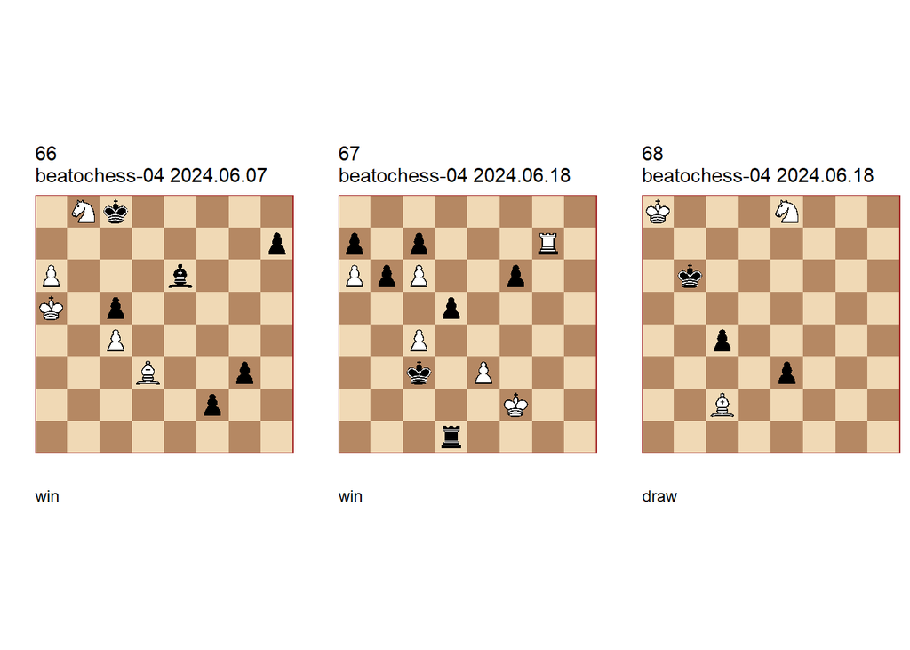

**66** correction of Hildebrand 1945 (+0041.24a5c7) U3. **1. a7** (1. Kb6? g2 2. a7 f1=Q 3. a8=Q Qf6!) **1… Kb7 2. Bf1 Kxa7 3. Nc6+ Ka8 4. Bg2 f1=Q 5. Bxf1 Bxc4 6. Bg2 1-0**.

**67** Tidskrift for Schack=2 Tidskrift for Schack/2 U3: Neuenschwander=B beatochess 02/07/2024. **1. c5!** (1. Rxc7? Kxc4 2. Rxa7 Kb5 3. c7 Rc1) **1… Kb4 2. cxb6 cxb6 3. Rg4+ Kb5** (3… Kb3! **cook** **BN** 4. Rc4 dxc4 5. c7 c3 6. c8=Q c2) **4. Rc4! dxc4 5. c7 1-0**.

**68** version of Hannemann 1945 (=0011.02b8b3) U1 U2. **1. Bd1 c3 2. Nf6 Ka5 3. Nd5 c2** (3… e2 **main** 4. Bxe2 c2 5. Ba6! c1=Q 6. Kb7) **4. Bxc2 e2 5. Ba4! e1=Q 6. Bc6 1/2-1/2**.

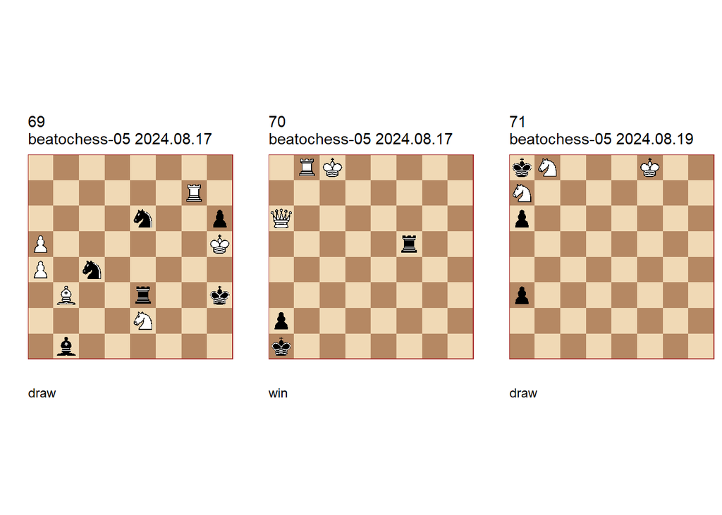

**69** correction of Steniczka 1991 (=0447.11h5h3) U3. **1. Rg3+! Rxg3 2. Nxg3 Nf4+ 3. Kxh6 Nxa5** (3… Nd2 4. Ne2! (4. Nh5? Nxh5 5. Bd5 Kh4 6. a6 Ne4 7. a7 Nef6 8. Be6 Be4) (4. a6? Kxg3) 4… Nxe2 5. Bd5 Nc3 6. Bb7) **4. Nh5! Nxh5 5. Be6+ Kh4 6. Bf5! Ba2 7. Bb1! Bb3 8. Bc2 Bc4 9. Bd3 Bd5 10. Be4 Bf7 11. Bg6 Bg8 12. Bh7 Ba2 13. Bb1 Bxb1 1/2-1/2**.

**70** correction of Heuacker 1938 (+1400.01c8a1) U1. **1. Qh6!** (1. Qe2? Rf8+ 2. Kc7 Rxb8 3. Qe5+ Kb1) (1. Ra8? Rf8+ 2. Kb7 Rxa8) (1. Rb6? Rc5+ 2. Kd7 Rd5+ 3. Ke6 Re5+ 4. Kd6 Rd5+ 5. Kc6 Rc5+ 6. Kb7 Rc7+ 7. Ka8 Rc8+) (1. Qc6? Rc5) **1… Rf8+** (1… Rc5+ 2. Kb7 Rb5+ 3. Kc6 Rc5+ 4. Kb6) **2. Kc7** (2. Kb7? Rxb8+) (2. Kd7 or ) **2… Rxb8** (2… Rf7+ 3. Kb6) **3. Qc1+ Rb1 4. Qc3+ Rb2 5. Qd4 Kb1 6. Qd1# 1-0**.

**71** correction of Heuacker 1928 (=0002.01f8a8) U1. **1. Nac6!** (1. Nbc6? a2 2. Na5 Kxa7 3. Nb3 Kb6) **1… a2** (1… Kb7 2. Nb4) **2. Na5 a1=Q** (2… Kxb8 3. Nb3 Kc7 4. Ke7 Kc6 5. Ke6 Kb5 6. Kd5 Kb4 7. Na1 Kc3 8. Ke4 Kb2 9. Kd3 Kxa1 10. Kc2) **3. Nbc6! Qf6+** (3… Qe1 4. Kf7!) **4. Ke8!** (4. Kg8? Qf4 5. Kg7 Qf5 6. Kg8 Qf6 7. Kh7 Qg5 8. Kh8 Qg6) **4… Qd6 5. Kf7 Qh6 1/2-1/2**.

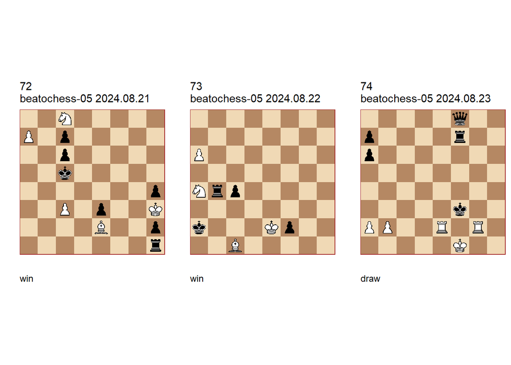

**72** correction of Heuacker 1935 (+0311.23h3c5) U1. **1. a8=R!** (1. a8=Q? Ra1 2. Qxa1 h1=Q+ 3. Qxh1) **1… Ra1 2. Rxa1 h1=Q+ 3. Rxh1 1-0**.

**73** correction of Heuacker 1939 (+0311.12g2b1) U2. **1. Nc3+ Ka1 2. a7 Rb8 3. Bb2+!** (3. Bf4? Ra8 4. Bb8 Kb2 5. Na4+ Kb3 6. Nb6 Rxa7 7. Bxa7 c3) **3… Rxb2+ 4. Kf1 Rb8 5. axb8=B! 1-0**.

**74** correction of Heuacker 1949 (=3500.11f1f3) U3. **1. a3!!** (1. a4? a5! 2. b3 a6! 3. Kg1 Zugzwang 3… Rf4! 4. Ref2+ Ke4 5. Rg4 Rxg4+) (1. b3? a5! 2. a3 Kf4 3. Kg1 a4! 4. b4 a5! 5. bxa5 Qc5+ 6. Ref2+ Ke4 7. Rg4+ Kd3 8. Rg3+ Kc4 9. Rg4+ Kb5) (1. b4? a5! 2. bxa5 Kf4 3. Kg1 (3. a6 Kf5) 3… Qc5+ ) **1… a5** (1… Kf4 2. Kg1 Qc5+ 3. Ref2+ Ke4 4. Rg4+ Kd3 5. Rg3+ Kc4 (5… Kd4 6. Rxf7) 6. Rc3+) (1… Rf4 2. Ref2+ Ke3 3. Rg3+ Ke4 4. Rg4) (1… Qd6 2. Rgf2+ (2. Ref2+? Ke3 3. Rxf7 Qd1#) 2… Kg3 3. Rxf7) (1… Qc5 2. Ref2+! ( 2. Rgf2+? Kg3 3. Rxf7 Qc1+ 4. Re1 Qc4+) 2… Ke3 3. Rg3+ Kd4 4. Rg4+) **2. a4!** (2. b3? Kf4 3. Kg1 a4!) **2… a6 3. b3!** Mutual Zugzwang **3… Kf4 4. Kg1 Qc5+ 5. Ref2+ Ke4 6. Rg4+ Kd3 7. Rg3+ Ke4 8. Rg4+ 1/2-1/2**.

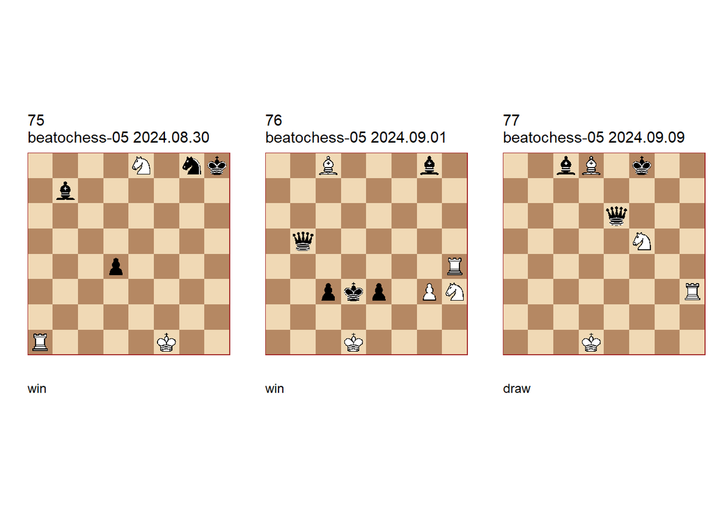

**75** version of Heuacker 1952 (+0134.01f1h8) U2. **1. Ra2!** (1. Ra5? Nh6 2. Rh5 Kh7 3. Nd6 Ba6+ 4. Ke1 Kg6) **1… Nh6** (1… Ne7 2. Ra7) **2. Rh2 Ba6+** (2… Kh7 3. Nd6 Ba6+ leads to the **main** line ) **3. Ke1!** (3. Kf2? Kh7 4. Nd6 Kg6 5. Rg2+ Kf6) **3… Kh7 4. Nd6 Kg6 5. Rg2+! Kf6** (5… Kh5 **main** line 6. Rg3! (6. Kd2? Ng4!) 6… Ng4 (6… d3 7. Kd2 and the black bishop will be captured eventually ) (6… Ng4 7. Ra3) 7. Ra3) **6. Kd2!** (6. Rg3? Nf5! 7. Rf3 Bd3!) **6… Bf1** (6… Nf5 7. Rf2) **7. Rf2+ Ke6 8. Rxf1 Kxd6 9. Rf6+ 1-0**.

**76** version of Heuacker 1954 (+3141.01d1c4) U3 U1. **1. Nf4+ Kc4** (1… Ke4 2. Ne2+ (2. Ne6+ or ) 2… Kf3 3. Nd4+ Kf2 4. Rf4+ Kxg3 5. Rg4+) **2. Ba6!** (2. Ne6+? Kb3 3. Nd4+ Kb2 4. Rh2+ e2+! 5. Rxe2+ Qxe2+ 6. Nxe2 Bb3+ 7. Ke1 Bc4 8. Bf5 c2) **2… Qxa6** (2… c2+ 3. Kxc2 Qxa6 4. Ne6+) **3. Ne6+ Kb3 4. Nc5+ Kb2 5. Rb4+ Bb3+ 6. Rxb3+ Ka2 7. Nxa6 Kxb3 8. Nc5+** (8. Ke2? Kc4) **8… Kc4 9. Ne6** (9. Ne4? Kd4!) **9… Kd3 10. Nf4+ Kd4** (10… Ke4 11. Ke2 c2 12. Nd3 Kd4 13. Nc1) **1-0**.

**77** correction of Heuacker 1967 (=3141.00d1f8) U3. **1. Be7+** (1. Rh8+? Kf7 2. Rh7+ Kg8 3. Rg7+ Kh8) **1… Kf7 2. Nd6+ Kxe7** (2… Kg8 3. Rg3+ Kh7 4. Nxc8) **3. Re3 Qxe3 4. Nf5+ Bxf5 1/2-1/2**.

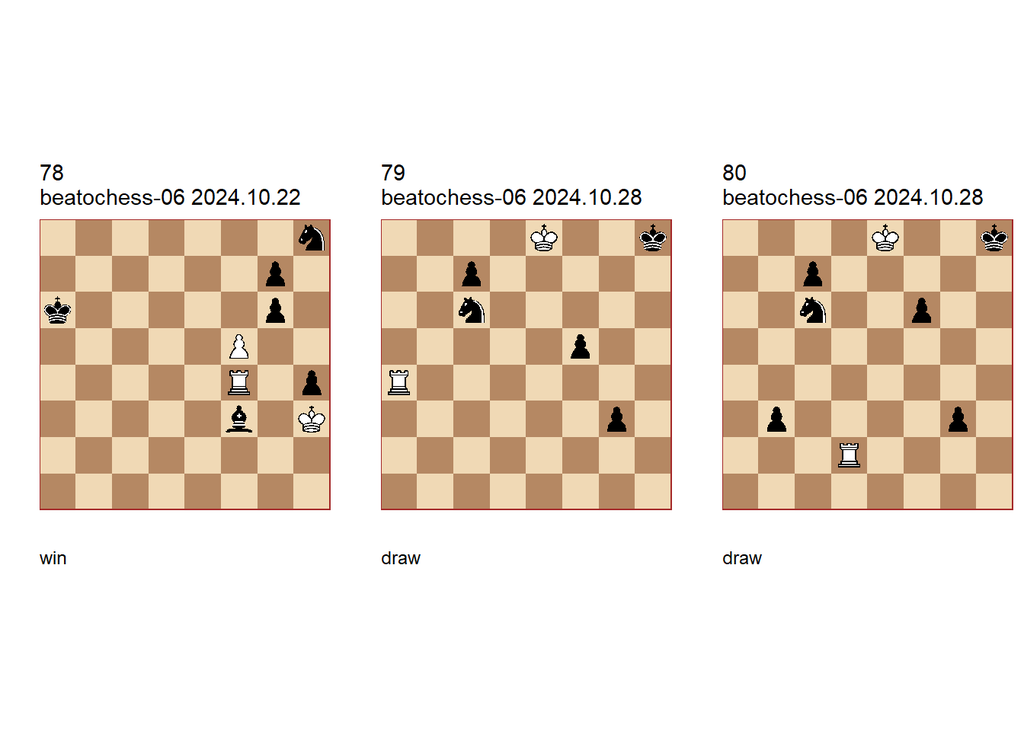

**78** correction of Mattison 1922 (+0133.12h3a6) U2. **1. f6 Bd5 2. fxg7 Nf7 3. Rd4** ( 3. Rf5? Be6! (3… gxf5? 4. g8=Q +-) 4. Kg2 (4. Kxh4 Nd6) (4. Kh2 Nh6) 4… h3+! (4… Bxf5? 5. g8=Q h3+ 6. Kg3 +- tablebase ) 5. Kg1 (5. Kh2 Nh6) 5… Bxf5 6. g8=Q Nd6 = tablebase ) **3… Bb3 4. Rd3 Bc4** (4… Be6+ 5. Kxh4) **5. Rc3 Bd5** (5… Be6+ 6. Kxh4 Nh6 7. Rc6+ Kb5 8. Rxe6 Nf5+ 9. Kg5 Nxg7 10. Re5+ Kc4 11. Kxg6) (5… Bf1+ 6. Kxh4 Nh6 7. Kg5 Ng8 8. Rc8 Ne7 9. Re8) **6. Rc5 Bb3 7. g8=Q Ng5+ 8. Rxg5 Bxg8 9. Rxg6+ 1-0**.

**79** correction of Mattison 1913 (=0103.02e8h8) U1. **1. Ra3!** (1. Kf7? Ne5+) ( 1. Kf8? Kh7) **1… f4 2. Rf3! g2 3. Rxf4 Ne5!** (3… g1=Q **main** 4. Rh4+ Kg7 5. Rg4+! Qxg4) **4. Rf5! g1=Q** (4… Nf3 5. Kf7) **5. Rh5+ Kg7 6. Rg5+! Qxg5 1/2-1/2**.

**80** version of Mattison 1913 (=0103.02e8h8) U1. **1. Rg2** ( Try: 1. Rb2? Nd4 2. Kf7 c5 3. Rg2 Nf5 4. Kxf6 c4 5. Kxf5 c3 6. Kg6 b2 7. Rg1 Kg8) **1… b2 2. Rxb2 f5 3. Rb3 f4 4. Rf3 Ne5** (4… g2 **main** 5. Rxf4 g1=Q 6. Rh4+ Kg7 7. Rg4+ Qxg4 ) **5. Rxf4 g2 6. Rf5 g1=Q 7. Rh5+ Kg7 8. Rg5+ Qxg5 1/2-1/2**.

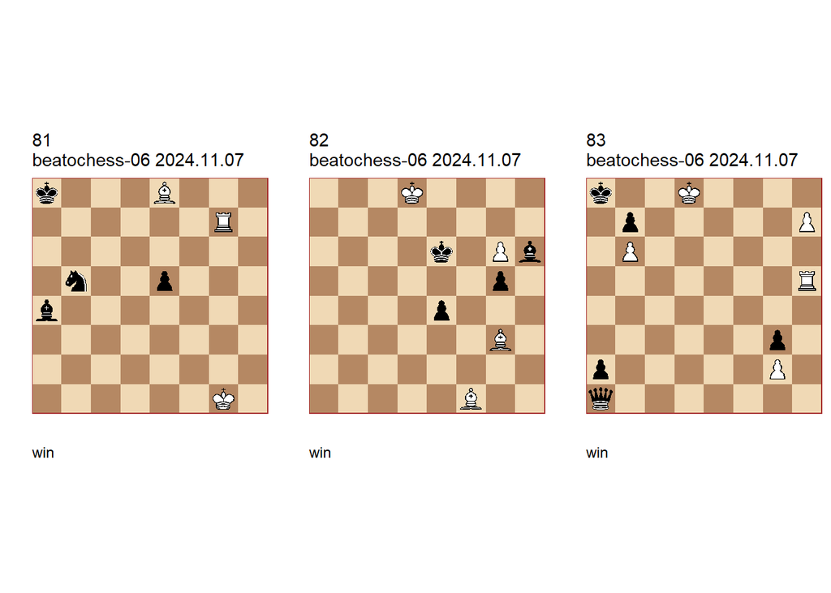

**81** correction of Gorgiev 1929 (+0143.00f1h8) U1 U2. **1. Bc6+** (1. Rg4? Bd1! 2. Rg8 Nc3!) (1. Rg2? Kb7! 2. Ra2 (2. Rg4 e4! 3. Rxe4 Nc3) 2… Nc3) (1. Kf2? Nc3!) **1… Kb8 2. Rb7+ Kc8 3. Rb6 Kc7 4. Ra6 Nc3 5. Bxa4 Kb7 6. Ra5 Kb6 7. Ra8 Kb7 8. Bc6+ Kxc6 9. Rc8+ 1-0**.

**82** correction of Bazlov 1974 (+0050.11d8e6) U1. **1. Bg2 Kf5 2. Ke7 Kxg6 3. Bxe4+ Kh5 4. Kf7 Kg4** (4… g4 5. Bg6+ Kg5 6. Be1) **5. Bd6!** (5. Bc7? Kh3 6. Kg6 Bf8 ) **5… Kh5 6. Be7 g4** (6… Kg4 7. Kg6) **7. Bg6# 1-0**.

**83** correction of Asaba 1974 (+3100.33d8a8) (c) U2. **1. h8=Q Qxh8+ 2. Rxh8 a1=Q 3. Rg8 Qa2 4. Rf8 Qa3** (4… Qf2 5. Ke7+) **5. Ke8 Kb8 6. Kf7+ Qxf8+ 7. Kxf8 Kc8 8. Ke7 Kb8 9. Kd7 1-0**.

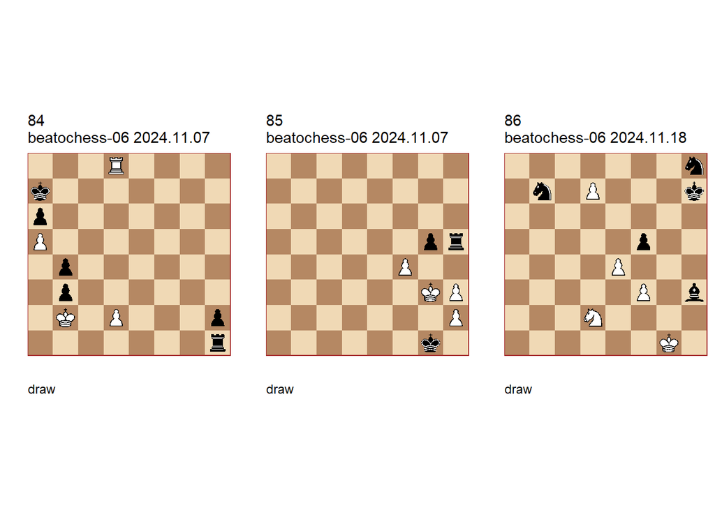

**84** correction of Maksimovskikh 1974 (=0400.24b2a7) U2. **1. Rd7+ Kb8** (1… Ka8 2. Rh7 Kb8 3. d4!) **2. Rh7 Kc8 3. d3! Kd8 4. d4 Ke8 5. d5 Kf8 6. d6 Ke8 7. Re7+ Kd8 8. Rh7 Kc8 9. Rc7+ Kd8 1/2-1/2**.

**85** correction of Asaba 1974 (=0300.31d3d1) U3. **1. f5 Rh4 2. f6 Rf4** (2… Rh6 3. Kg4 Rxf6 4. Kxg5 Rf8 5. h4 Kxh2 6. h5) **3. h4 Rxh4 4. f7 Rf4** (4… Rh8 5. Kg4 Rf8 6. Kxg5 Rxf7 7. h4) **5. h4 Rxf7 6. hxg5 1/2-1/2**.

**86** correction of Belikov/Kusnetsov 1974 (=0037.31h1h7) U3 **1. Kh2 fxe4 2. Nxe4 Bf1 3. Kg1 Be2 4. Kf2 Bd1 5. Ke1 Bc2 6. Kd2 Bb1 7. Kc1 Ba2 8. Kb2 1/2-1/2**.

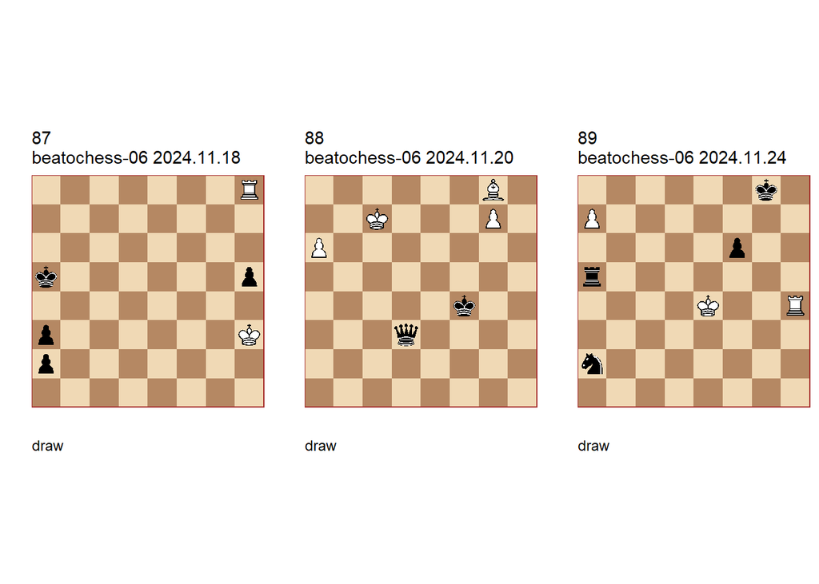

**87** correction of Bakay 1954 (=0100.03h3b5) U2 U3. **1. Ra8+ Kb4 2. Rb8+ Kc3 3. Rc8+ Kd2 4. Rd8+ Ke2 5. Re8+ Kf2 6. Rf8+ Kg1 7. Rg8+** (7. Re8? a1=R!) **7… Kh1 8. Re8 a1=R 9. Re3 1/2-1/2**.